# STAT380_HW9

Name

Due: Due on Thursday, April 24, 2025 by 11:59 PM)

## Instructions

In class, we introduced 3 methods for selecting the features to be included in a model (forward, backward, LASSO). The activities that follow are meant to provide further practice with these concepts. NOTE: All required `library` commands **must be** included in the Front Matter section. If you include your `library` commands elsewhere in your code, you will be penalized.

At the conclusion to the activity, you should upload

1. your .html file named LastnameFirstInitial_STAT380_HW9.html
2. your .Rmd file named LastnameFirstInitial_STAT380_HW9.Rmd

## Learning Objectives

This assignment address aspects of the following learning objectives.

1. Students will be able to load datasets from R packages and external sources into the R environment.
2. Given a statistical learning method, students will be able to restructure the data for use in the corresponding R function.
3. Identify the best subset of predictors for a linear regression model using subset selection methods, such as best subsets or stepwise regression, using statistical software.
4. Apply shrinkage/regularization methods for estimating parameters using statistical software, including selecting a value for the tuning parameter using cross validation.
5. Interpret the results of LASSO in the context of feature selection.
6. Compare the ability of competing models to generalize for new data.

## Front Matter - Clean Environment, Load Libraries, User Defined Functions

```r
rm(list = ls())
#Add libraries as needed
library(tidyverse)
library(glmnet) #To perform LASSO and Ridge
library(rpart) #For regression and classification trees
library(rattle) #For nice visualization of trees
#Read in dataset
MLB <- read.csv("C:/Users/Blungus/OneDrive - The Pennsylvania State University/2024-25/Spring Sem/Stat 380/Test CSV files/MLB.csv")
```

## Problem 1. Baseball Data

`MLB.csv` contains information about a sample of Major League Baseball (MLB) players from the 1986 and 1987 seasons. Variables include:

- PlayerName-Player’s name
- AtBat-Number of times at bat in 1986
- Hits-Number of hits in 1986
- HmRun-Number of home runs in 1986
- Runs-Number of runs in 1986
- RBI-Number of runs batted in in 1986
- Walks-Number of walks in 1986
- Years-Number of years in the major leagues
- CAtBat-Number of times at bat during his career
- Chits-Number of hits during his career
- CHmRun-Number of home runs during his career
- CRuns-Number of runs during his career
- CRBI-Number of runs batted in during his career
- CWalks-Number of walks during his career
- League-factor with levels A (for American) and N (for National) indicating player’s league at the end of 1986
- Division-factor with levels E (for East) and W (for West) indicating player’s division at the end of 1986
- PutOuts-Number of put outs in 1986
- Assists-Number of assists in 1986
- Errors-Number of errors in 1986
- Salary-1987 annual salary on opening day in thousands of dollars
- NewLeague-factor with levels A (for American) and N (for National) indicating player’s league at the beginning of 1987

**Our goal is to predict a baseball player’s 1987 salary on the basis of the other variables in the dataset (excluding player name).**

1. Remove the `PlayerName` column and any players with a missing salary. Name the result `MLB2`. NOTE: `MLB2` should have 263 observations and 20 variables.

```r
MLB2 <- MLB %>%
  select(-PlayerName) %>%
  filter(!is.na(Salary))
```

2. In order to use the `glmnet` and/or `cv.glmnet` function for building LASSO regression models, create the input matrix and response variable vector.

```r
#Create input matrix and response vector
Xmat <- model.matrix(Salary ~ ., data = MLB2)[, -1]
yvec <- MLB2$Salary
```

3. Using a seed of 321, perform an 85/15 training/validation split.

```r
#Perform 80/20 training/validation split using seed of 321
set.seed(321)
trainInd <- sample(1:nrow(MLB2), floor(0.85*nrow(MLB2)))
set.seed(NULL)

#Split Xmat and yvec separately
XmatTrain <- Xmat[trainInd, ]
XmatValidation <- Xmat[-trainInd, ]

yvecTrain <- yvec[trainInd]
yvecValidation <- yvec[-trainInd]
```

4. Using a seed of 12345 and 10-fold cross validation on the training data, use the `cv.glmnet` function to create the plot of MSE as a function of $log(\lambda)$. NOTE: The seed mentioned in this problem should not be used to repeat the training/validation split. Instead, it is the seed for the `cv.glmnet` function which will do the 10-fold cross validation for you.

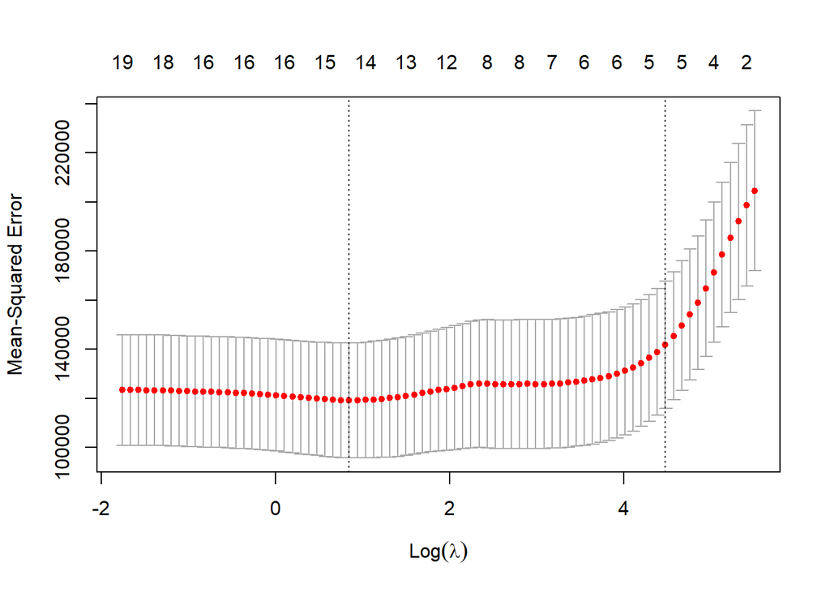

```r
#Use 10-fold CV to pick lambda for LASSO (use seed 123)
set.seed(12345)
lassoCV <- cv.glmnet(x = XmatTrain,
                     y = yvecTrain,
                     family = "gaussian",
                     alpha = 1,
                     lambda = NULL,
                     standardize = TRUE,
                     nfolds = 10)
set.seed(NULL)
#Show the LASSO CV results
plot(lassoCV)
```

5. What is the optimal $\lambda$ for LASSO regression based on using the minimum value of MSE rule? Which variables are included using this value of $\lambda$?
6. What is the optimal $\lambda$ for LASSO regression based on using the 1-standard error (1SE) rule? Which variables are included using this value of $\lambda$?

```r
#Display the optimal values of lambda
lassoCV$lambda.min
```

```
## [1] 2.333354
```

```r
lassoCV$lambda.1se
```

```
## [1] 87.84927
```

```r
#Store the coefficients associated with the optimal values
coefLamMin <- predict(lassoCV, s = lassoCV$lambda.min, type = "coefficients")
coefLam1se <- predict(lassoCV, s = lassoCV$lambda.1se, type = "coefficients")

#Create a data frame for comparing the coefficients
tempdf <-
  data.frame(Variable = row.names(coefLamMin),
             lamMin = as.numeric(coefLamMin),
             lam1se = as.numeric(coefLam1se))

tempdf
```

```
##       Variable       lamMin       lam1se
## 1  (Intercept)  163.2781754 188.76059943
## 2        AtBat   -2.3660670   0.00000000
## 3         Hits    7.5513065   1.14710006
## 4        HmRun    1.1695117   0.00000000
## 5         Runs    0.4902876   0.00000000
## 6          RBI    0.0000000   0.00000000
## 7        Walks    5.3416643   1.49868914
## 8        Years  -14.0617073   0.00000000
## 9       CAtBat    0.0000000   0.00000000
## 10       CHits    0.0000000   0.00000000
## 11      CHmRun    0.0000000   0.00000000
## 12       CRuns    0.7275583   0.22796338
## 13        CRBI    0.4558730   0.19373316
## 14      CWalks   -0.5089820   0.00000000
## 15     LeagueN   70.3973102   0.00000000
## 16   DivisionW -106.8440967   0.00000000
## 17     PutOuts    0.3033394   0.07866994
## 18     Assists    0.3027899   0.00000000
## 19      Errors   -3.0147250   0.00000000
## 20  NewLeagueN    0.0000000   0.00000000
```

7. Using the value of $\lambda$ associated with the minimum MSE, compute **and interpret** the RMSE on validation data.

```r
#LASSO
lassoYhat <- predict(lassoCV,
                     s = lassoCV$lambda.min,
                     newx = XmatValidation)



lassoMSE <- mean((yvecValidation - lassoYhat)^2)


lassoRMSE <- sqrt(lassoMSE)

lassoRMSE
```

```
## [1] 310.1718
```

When using 10-fold cross validation to determine the most optimal value of lamda for LASSO regression to predict player salaries in 1987 using selected variables, the average difference between our predicted values and actual values is roughly $310,172 (RMSE converted to thousands of dollars).

8. If you were to perform backward elimination for selecting the “best” subset of predictors for predicting salary, which variables would remain in the model?

```r
regTrain <- MLB2[trainInd, ]
regVal <- MLB2[-trainInd, ]
#Build Intercept Only Model. NOTE: ~ 1 tells R that you only want an intercept
int_only_model <- lm(Salary ~ 1,
                      data = regTrain)

#Build model with all potential regressors.

full_model <- lm(Salary ~ .,
                  data = regTrain)

#Perform backward elimination (variables taken away) using base-R
#Have R do it all
stepwise_model <- step(full_model,
                       scope = list(lower = int_only_model, upper = full_model),
                       direction = "backward")
```

```
## Start:  AIC=2590.42
## Salary ~ AtBat + Hits + HmRun + Runs + RBI + Walks + Years +
##     CAtBat + CHits + CHmRun + CRuns + CRBI + CWalks + League +
##     Division + PutOuts + Assists + Errors + NewLeague
##
##             Df Sum of Sq      RSS    AIC
## - NewLeague  1       267 20666583 2588.4
## - CHits      1       286 20666602 2588.4
## - Runs       1      5124 20671439 2588.5
## - CHmRun     1     53828 20720143 2589.0
## - Errors     1     58093 20724409 2589.0
## - CAtBat     1     62466 20728781 2589.1
## - Years      1     71123 20737438 2589.2
## - League     1    105389 20771704 2589.6
## - RBI        1    109277 20775592 2589.6
## - HmRun      1    149297 20815613 2590.0
## <none>                   20666315 2590.4
## - CRBI       1    227476 20893792 2590.9
## - CRuns      1    269791 20936106 2591.3
## - Assists    1    391980 21058295 2592.6
## - CWalks     1    504114 21170430 2593.8
## - Division   1    617077 21283392 2595.0
## - Walks      1   1142606 21808922 2600.4
## - Hits       1   1318154 21984469 2602.2
## - PutOuts    1   1458741 22125056 2603.6
## - AtBat      1   1546275 22212590 2604.5
##
## Step:  AIC=2588.42
## Salary ~ AtBat + Hits + HmRun + Runs + RBI + Walks + Years +
##     CAtBat + CHits + CHmRun + CRuns + CRBI + CWalks + League +
##     Division + PutOuts + Assists + Errors
##
##            Df Sum of Sq      RSS    AIC
## - CHits     1       379 20666962 2586.4
## - Runs      1      5120 20671703 2586.5
## - CHmRun    1     54946 20721529 2587.0
## - Errors    1     57887 20724470 2587.0
## - CAtBat    1     62201 20728783 2587.1
## - Years     1     70891 20737474 2587.2
## - RBI       1    109394 20775977 2587.6
```

[output cut: 147 more lines]

```
##     League + Division + PutOuts + Assists
##
##            Df Sum of Sq      RSS    AIC
## <none>                  20959710 2577.6
## - League    1    342618 21302328 2579.2
## - CAtBat    1    388260 21347970 2579.7
## - Assists   1    391947 21351657 2579.7
## - Division  1    534196 21493906 2581.2
## - CRBI      1    716199 21675908 2583.1
## - CWalks    1    791929 21751639 2583.8
## - CRuns     1   1126915 22086624 2587.2
## - Walks     1   1321272 22280982 2589.2
## - PutOuts   1   1637112 22596821 2592.3
## - AtBat     1   2312525 23272235 2598.9
## - Hits      1   2511200 23470910 2600.8
```

```r
summary(stepwise_model)
```

```
##
## Call:
## lm(formula = Salary ~ AtBat + Hits + Walks + CAtBat + CRuns +
##     CRBI + CWalks + League + Division + PutOuts + Assists, data = regTrain)
##
## Residuals:
##     Min      1Q  Median      3Q     Max
## -837.21 -169.07  -34.22  121.70 1846.01
##
## Coefficients:
##              Estimate Std. Error t value Pr(>|t|)
## (Intercept) 146.32878   78.26852   1.870 0.062928 .
## AtBat        -2.91558    0.60427  -4.825 2.68e-06 ***
## Hits          9.19319    1.82842   5.028 1.06e-06 ***
## Walks         6.28504    1.72331   3.647 0.000334 ***
## CAtBat       -0.11933    0.06036  -1.977 0.049342 *
## CRuns         1.42468    0.42298   3.368 0.000899 ***
## CRBI          0.63255    0.23557   2.685 0.007827 **
## CWalks       -0.79685    0.28222  -2.824 0.005205 **
## LeagueN      80.73787   43.47340   1.857 0.064679 .
## DivisionW   -99.62881   42.96216  -2.319 0.021353 *
## PutOuts       0.32279    0.07951   4.060 6.92e-05 ***
## Assists       0.33317    0.16773   1.986 0.048285 *
## ---
## Signif. codes:  0 '***' 0.001 '**' 0.01 '*' 0.05 '.' 0.1 ' ' 1
##
## Residual standard error: 315.2 on 211 degrees of freedom
## Multiple R-squared:  0.5409, Adjusted R-squared:  0.5169
## F-statistic:  22.6 on 11 and 211 DF,  p-value: < 2.2e-16
```

1. Based on the RMSE for the validation data, which model (the model selected by LASSO regression with $\lambda$ based on the minimum MSE OR the model selected by backward elimination) produced a better RMSE on the validation data? Justify your answer. (Your answer should include the value of the RMSE for both models.)

```r
stepPredict <- predict(stepwise_model, newdata = regVal)

stepRMSE <- sqrt(mean((regVal$Salary-stepPredict)^2))

lassoRMSE
```

```
## [1] 310.1718
```

```r
stepRMSE
```

```
## [1] 311.0321
```

RMSE values * LASSO-CV: + **310.1718** * stepwise: + 311.0321

Based on our results, we can conclude that the 10-fold cross validation to find an optimal lambda value for LASSO regression was better at lowering the average difference in predicted player salary in 1987 when compared to their actual salaries. Although the results are close, the LASSO model fits the data better and contains more precise predictions than the stepwise model.